# 1. Predicting Samsung Stock Prices Using LSTM

This project will predict the closing stock prices of Samsung using all kinds of RNN models, such as a

- Univariate
- Bidirectional
- Stacked

LSTM model.

[Data used](https://www.kaggle.com/datasets/ranugadisansagamage/samsung-stocks)

```python
import numpy as np
import pandas as pd
import matplotlib.pyplot as plt

from tensorflow.keras.models import Sequential
from tensorflow.keras.layers import LSTM, Bidirectional, Dense, Activation, Dropout
from sklearn.preprocessing import StandardScaler
from sklearn.metrics import mean_squared_error, r2_score
from sklearn.utils import shuffle
```

```python
df = pd.read_csv('samsung.csv')
```

## 2. Data Exploration

```python
df.info()
```

```
<class 'pandas.core.frame.DataFrame'>
RangeIndex: 5621 entries, 0 to 5620
Data columns (total 7 columns):
 #   Column     Non-Null Count  Dtype
---  ------     --------------  -----
 0   Date       5621 non-null   object
 1   Open       5621 non-null   float64
 2   High       5621 non-null   float64
 3   Low        5621 non-null   float64
 4   Close      5621 non-null   float64
 5   Adj Close  5621 non-null   float64
 6   Volume     5621 non-null   int64
dtypes: float64(5), int64(1), object(1)
memory usage: 307.5+ KB
```

```python
df.head()
```

|  | Date | Open | High | Low | Close | Adj Close | Volume |
| --- | --- | --- | --- | --- | --- | --- | --- |
| 0 | 2000-01-04 | 6000.0 | 6110.0 | 5660.0 | 6110.0 | 4651.737793 | 74195000 |
| 1 | 2000-01-05 | 5800.0 | 6060.0 | 5520.0 | 5580.0 | 4248.232422 | 74680000 |
| 2 | 2000-01-06 | 5750.0 | 5780.0 | 5580.0 | 5620.0 | 4278.686523 | 54390000 |
| 3 | 2000-01-07 | 5560.0 | 5670.0 | 5360.0 | 5540.0 | 4217.780273 | 40305000 |
| 4 | 2000-01-10 | 5600.0 | 5770.0 | 5580.0 | 5770.0 | 4392.884766 | 46880000 |

```python
df.describe()
```

|  | Open | High | Low | Close | Adj Close | Volume |
| --- | --- | --- | --- | --- | --- | --- |
| count | 5621.000000 | 5621.000000 | 5621.000000 | 5621.000000 | 5621.000000 | 5.621000e+03 |
| mean | 24884.228785 | 25135.306885 | 24627.612524 | 24879.640633 | 21729.421164 | 2.176271e+07 |
| std | 20108.258909 | 20274.093474 | 19934.697294 | 20094.098853 | 19740.261271 | 1.545201e+07 |
| min | 2540.000000 | 2760.000000 | 2420.000000 | 2730.000000 | 2078.436279 | 0.000000e+00 |
| 25% | 10160.000000 | 10320.000000 | 10020.000000 | 10160.000000 | 7780.813477 | 1.179815e+07 |
| 50% | 16580.000000 | 16800.000000 | 16420.000000 | 16600.000000 | 13287.424805 | 1.774055e+07 |
| 75% | 31320.000000 | 31600.000000 | 30940.000000 | 31340.000000 | 26643.304688 | 2.722500e+07 |
| max | 90300.000000 | 96800.000000 | 89500.000000 | 91000.000000 | 88908.179688 | 1.642150e+08 |

Data Exploration of all the relevant features in the dataset.

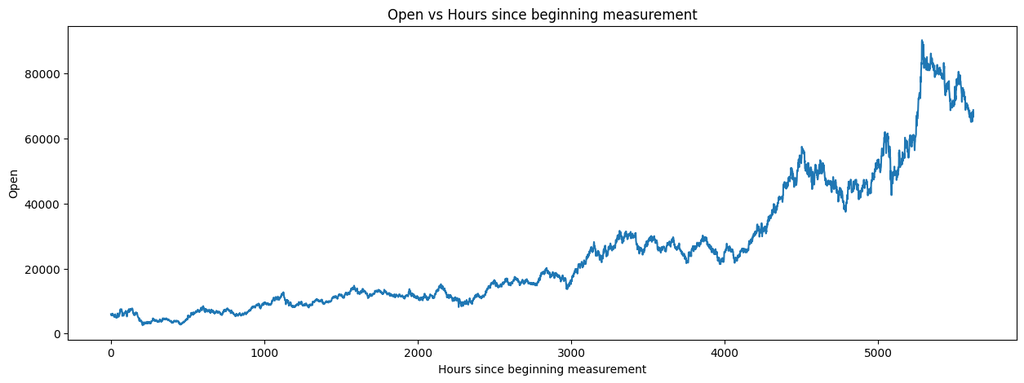

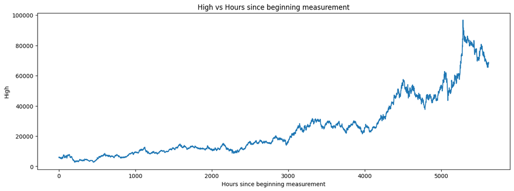

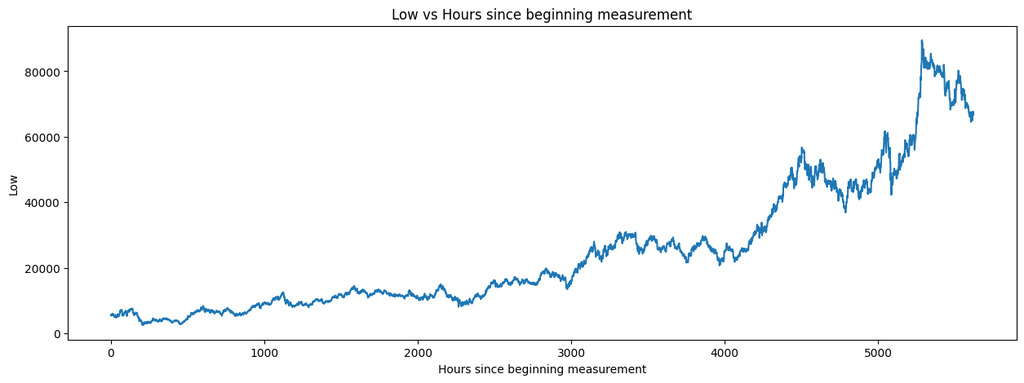

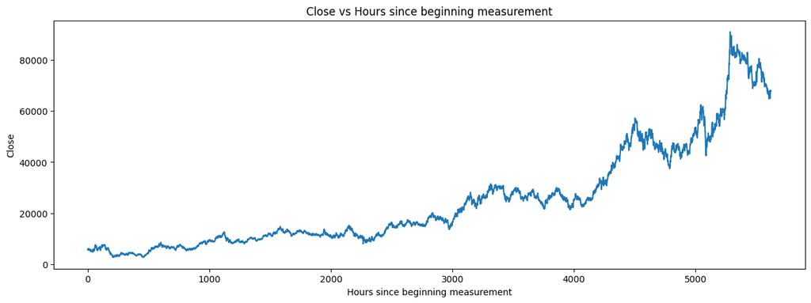

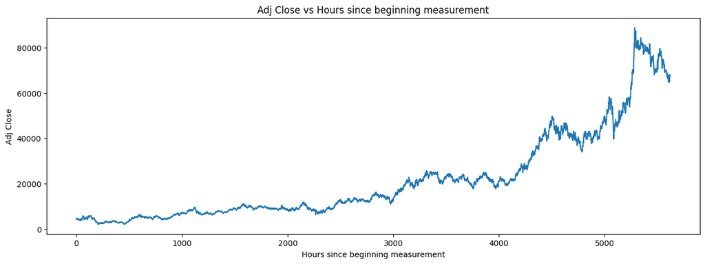

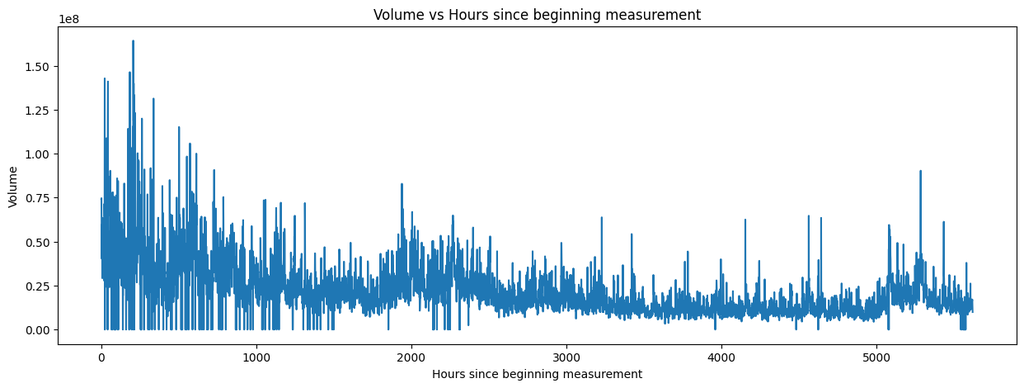

```python
# Some data exploration

columns = ['Open', 'High', 'Low', 'Close', 'Adj Close', 'Volume']

for col in columns:
	plt.figure(figsize = (15, 5))
	plt.plot(df[col])
	plt.xlabel("Hours since beginning measurement")
	plt.ylabel(col)
	plt.title(col + " " + "vs Hours since beginning measurement")
	plt.show()
```

You can see that these is not a lot of change in the different features, which is why we will only use the closing price for our predictions. It is also the most important feature for predicting stock prices.

## 3. Univariate LSTM Model

### 3.1 Data Preprocessing

```python
df_uni = df['Close']
df_uni = df_uni.values.astype('float32')
df_uni
```

```
array([ 6110.,  5580.,  5620., ..., 67500., 68000., 67900.], dtype=float32)
```

```python
# standardize the data

scaler = StandardScaler()
scaler.fit(df_uni.reshape(-1, 1))
data_stand = scaler.transform(df_uni.reshape(-1, 1))
data_stand
```

```
array([[-0.9341703],
       [-0.9605486],
       [-0.9585577],
       ...,
       [ 2.1212273],
       [ 2.1461124],
       [ 2.1411355]], dtype=float32)
```

```python
# train test split 80-20

train_size = int(len(data_stand) * 0.80)
test_size = len(data_stand) - train_size
train, test = data_stand[0:train_size,:], data_stand[train_size:len(data_stand),:]
print(len(train), len(test))
```

```
4496 1125
```

```python
# create a function to process the data into a form that can be fed into the model

def create_dataset(dataset, look_back = 1):
	dataX, dataY = [], []
	for i in range(len(dataset) - look_back - 1):
		a = dataset[i:(i + look_back), 0]
		dataX.append(a)
		dataY.append(dataset[i + look_back, 0])
	return np.array(dataX), np.array(dataY)
```

```python
# reshape into X=t and Y=t+1

look_back = 1
X_train, y_train = create_dataset(train, look_back)
X_test, y_test = create_dataset(test, look_back)
```

```python
# reshape input to be [samples, time steps, features]

X_train = np.reshape(X_train, (X_train.shape[0], 1, X_train.shape[1]))
X_test = np.reshape(X_test, (X_test.shape[0], 1, X_test.shape[1]))
```

```python
from keras.layers import Dropout
from keras.callbacks import EarlyStopping

model = Sequential()
model.add(LSTM(128, input_shape=(1, look_back), return_sequences=True))
model.add(Dropout(0.2))
model.add(LSTM(64))
model.add(Dropout(0.2))
model.add(Dense(1, activation='linear'))

model.compile(loss='mean_squared_error', optimizer='adam')

early_stopping = EarlyStopping(patience=10, restore_best_weights=True)
fit1 = model.fit(X_train, y_train, epochs=100, batch_size=32, verbose=1, validation_split=0.2, callbacks=[early_stopping])
```

```python
def predict_and_score(model, X, Y):
    pred = scaler.inverse_transform(model.predict(X))
    orig_data = scaler.inverse_transform([Y])
    score = np.sqrt(mean_squared_error(orig_data[0], pred[:, 0]))
    return (score, pred)

rmse_train, train_predict = predict_and_score(model, X_train, y_train)
```

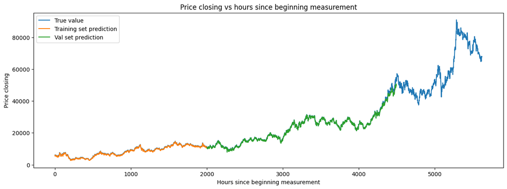

```python
size = 2000

train_predict_plot = np.empty_like(data_stand)
train_predict_plot[:, :] = np.nan
train_predict_plot[(look_back):size + look_back, :] = train_predict[0:size]


val_predict_plot = np.empty_like(data_stand)
val_predict_plot[:, :] = np.nan
val_predict_plot[size + look_back:len(train_predict) + look_back, :] = train_predict[size:len(train_predict)]


# Plot.
plt.figure(figsize = (15, 5))
plt.plot(scaler.inverse_transform(data_stand), label = "True value")
plt.plot(train_predict_plot, label = "Training set prediction")
plt.plot(val_predict_plot, label = "Val set prediction")

plt.xlabel("Hours since beginning measurement")
plt.ylabel("Price closing")
plt.title("Price closing vs hours since beginning measurement")
plt.legend()
plt.show()
```

This model look pretty good. We will not use the test set yet, because this will introduce bias into the models. We will use the test set later to see how well our model performs on unseen data.

### 3.3 Model Building (Stacked LSTM)

```python
from keras.callbacks import EarlyStopping

def fit_model(train_X, train_Y, look_back=3):
    model = Sequential()

    model.add(LSTM(50, activation='relu', return_sequences=True, input_shape=(1, look_back)))
    model.add(LSTM(50, activation='relu'))
    model.add(Dense(1))
    model.compile(loss = "mean_squared_error",
                  optimizer = "adam")
    early_stopping =  EarlyStopping(patience=10,  restore_best_weights=True)
    model.fit(train_X,
              train_Y,
              epochs = 100,
              batch_size = 1,
              verbose = 1,
              callbacks=[early_stopping],
              validation_split=0.2)

    return model

model2 = fit_model(X_train, y_train, look_back)
```

```python
# Get predictions

def predict_and_score(model, X, Y):
    pred = scaler.inverse_transform(model.predict(X))
    orig_data = scaler.inverse_transform([Y])

    score = np.sqrt(mean_squared_error(orig_data[0], pred[:, 0]))
    return(score, pred)

r2_train, train_predict2 = predict_and_score(model2, X_train, y_train)
```

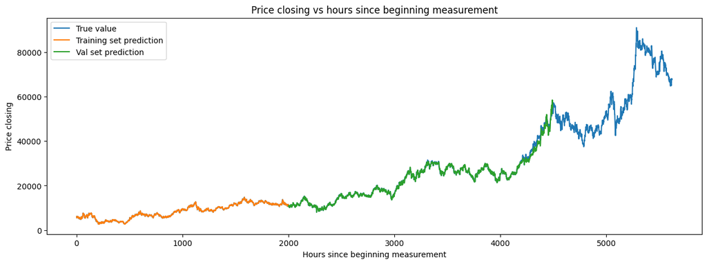

```python
train_predict_plot = np.empty_like(data_stand)
train_predict_plot[:, :] = np.nan
train_predict_plot[(look_back):size + look_back, :] = train_predict2[0:size]

val_predict_plot = np.empty_like(data_stand)
val_predict_plot[:, :] = np.nan
val_predict_plot[size + look_back:len(train_predict) + look_back, :] = train_predict2[size:len(train_predict2)]


plt.figure(figsize = (15, 5))
plt.plot(scaler.inverse_transform(data_stand), label = "True value")
plt.plot(train_predict_plot, label = "Training set prediction")
plt.plot(val_predict_plot, label = "Val set prediction")

plt.xlabel("Hours since beginning measurement")
plt.ylabel("Price closing")
plt.title("Price closing vs hours since beginning measurement")
plt.legend()
plt.show()
```

### 3.4 Model Building (Bidirectional LSTM)

```python
def fit_model(train_X, train_Y, look_back=3):
    model = Sequential()

    model.add(Bidirectional(LSTM(128, activation='relu', return_sequences=True, input_shape=(1, look_back))))
    model.add(Dropout(0.2))
    model.add(Bidirectional(LSTM(64, activation='relu')))
    model.add(Dropout(0.2))
    model.add(Dense(32, activation='relu'))
    model.add(Dense(1))

    model.compile(loss="mean_squared_error", optimizer="adam")

    early_stopping = EarlyStopping(patience=15, restore_best_weights=True)

    model.fit(train_X, train_Y, epochs=100, batch_size=32, verbose=1, callbacks=[early_stopping], validation_split=0.2)

    return model

model3 = fit_model(X_train, y_train, look_back)
```

```python
# Get predictions

def predict_and_score(model, X, Y):
    pred = scaler.inverse_transform(model.predict(X))
    orig_data = scaler.inverse_transform([Y])
    score = np.sqrt(mean_squared_error(orig_data[0], pred[:, 0]))
    return(score, pred)

r2_train, train_predict3 = predict_and_score(model3, X_train, y_train)
```

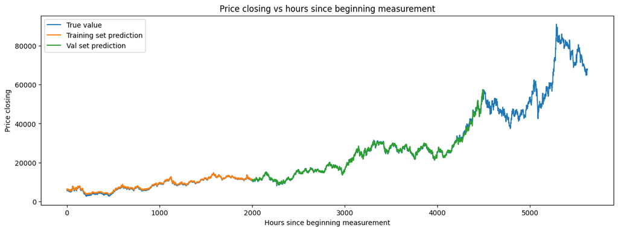

```python
train_predict_plot = np.empty_like(data_stand)
train_predict_plot[:, :] = np.nan
train_predict_plot[(look_back):size + look_back, :] = train_predict3[0:size]

val_predict_plot = np.empty_like(data_stand)
val_predict_plot[:, :] = np.nan
val_predict_plot[size + look_back:len(train_predict) + look_back, :] = train_predict3[size:len(train_predict3)]

plt.figure(figsize = (15, 5))
plt.plot(scaler.inverse_transform(data_stand), label = "True value")
plt.plot(train_predict_plot, label = "Training set prediction")
plt.plot(val_predict_plot, label = "Val set prediction")

plt.xlabel("Hours since beginning measurement")
plt.ylabel("Price closing")
plt.title("Price closing vs hours since beginning measurement")
plt.legend()
plt.show()
```

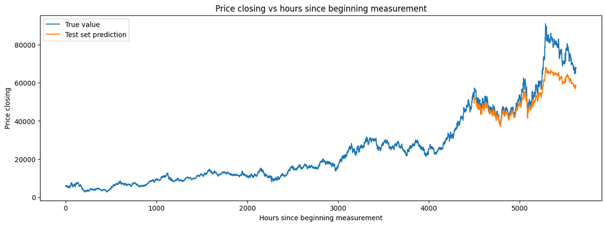

```python
# Predictions on test set

r2_test, test_predict = predict_and_score(model, X_test, y_test)

test_predict_plot = np.empty_like(data_stand)
test_predict_plot[:, :] = np.nan

test_predict_plot[len(train_predict) + (look_back * 2) + 1:len(data_stand) - 1, :] = test_predict

plt.figure(figsize = (15, 5))
plt.plot(scaler.inverse_transform(data_stand), label = "True value")
plt.plot(test_predict_plot, label = "Test set prediction")

plt.xlabel("Hours since beginning measurement")
plt.ylabel("Price closing")
plt.title("Price closing vs hours since beginning measurement")
plt.legend()
plt.show()
```

```python
# Scores on train and test sets

print("Training data score: %.2f RMSE" % r2_train)
print("Test data score: %.2f RMSE" % r2_test)
```

```
Training data score: 510.24 RMSE
Test data score: 8579.83 RMSE
```

```python
import csv
from datetime import datetime, timedelta

start_date = datetime(2022, 5, 24)
input_sequence = X_test[-look_back:]
input_sequence = np.reshape(input_sequence, (1, look_back, 1))

predictions = []
dates = []

for _ in range(30):
	next_prediction = model.predict(input_sequence)
	predictions.append(next_prediction[0, 0])

	input_sequence = np.append(input_sequence[:, 1:, :], np.expand_dims(next_prediction, axis=1), axis=1)

	start_date += timedelta(days=1)
	dates.append(start_date.strftime("%Y-%m-%d"))

predictions = scaler.inverse_transform([predictions])[0]

with open('predictions.csv', 'w', newline='') as file:
	writer = csv.writer(file)
	writer.writerow(['Date', 'Predicted Closing Price'])
	for date, prediction in zip(dates, predictions):
		writer.writerow([date, prediction])

print("Predictions saved to predictions.csv file.")
```

```
Predictions saved to predictions.csv file.
```